# Introduction to R:loa

Karl Ropkins

2021-04-10

## R:loa

This note provides an brief background and overview introduction to the **R** package **loa**.

The **lattice**[^1] package that comes with **R** draws graphs.

**loa** is short for **L**attice **O**ptional extras and **A**dd-ins, and that pretty much describes **loa**.

> This note assumes you already have R. If not but the note is of interest, **R** is open-source and free-to-distribute, and you can get it from [>The R Project](https://www.r-project.org/).

## Background

I originally packaged **loa** because I had a lot of plot code, most modifications of or extensions to existing **lattice** code, that I was using and replicating in several projects and I wanted to rationalise things.

The intention was also to automate and simplify some of the data handling needed when **lattice** plotting[^2].

## Getting loa

Installing **loa** from CRAN, the main R package archive:

```r
#In R, type:
install.packages("loa")
```

Installing the developers version:

```r
install.packages("loa", repos="http://R-Forge.R-project.org")
```

To load **loa** once it is installed:

```r
library(loa) #or require(loa)
```

> Note: **loa** automatically also loads **lattice** so you, as well as **loa**, have access to **lattice**.

## The loa Inventory

**loa** version 0.2.47.1[^3] contains:

- Several plot functions, e.g. **loaPlot()**, **RgoogleMapsPlot()** and **trianglePlot()**;
- Add-ins like **panel** functions to change plot outputs; and
- Some functions to automate handling of some of the more mundane plot parameters.

**loa** also contains one data set, **lat.lon.meuse**, and one map, **roadmap.meuse**, which are used in examples in the **loa** documentation.

## The Datasets

**lat.lon.meuse** is a **data.set** containing metal concentrations measured in soil and sediment samples collected from a section of the Meuse floodplain in the Netherlands.

It is a modification of the **meuse** **data.set** in the **sp** package.[^4] It contains concentrations of four metals (**cadmium**, **copper**, **lead** and **zinc**), sampling location (**latitude**, **longitude**, **elevation**), and other related information (e.g. **soil** type) for 155 locations.

**roadmap.meuse** is a Google Map ‘roadmap’ for the meuse area used as a map layer in off-line **GoogleMap()** examples.

There are further details on both in the package documentation, see **?lat.lon.meuse** or **?roadmap.meuse**.

## Working with loa

**loa** uses **lattice** plotting strategies[^5].

Plot dimensions are set using a formula as the first argument of the plot command.

> For those unfamiliar with the approach, it is probably easiest to think of a **lattice** plot as a model like **lm()** but with a formula that maps one term onto a series of axes rather than a series of inputs.

For example, **loaPlot()** uses a formula structure **z ~ x * y | cond**, where:

- **x** and **y** are the x and y axes,
- **z** is an optional term controlling the appearance (color and size) of points plotted at (x, y), and
- **cond**, also optional, is any additional term that can be used to subsample (x,y,z) data when plotting subsets separately.

The formula terms may be supplied directly or taken from a source identified using a second optional plot argument **data**. If supplied, **data** should be a **data.frame** or something that can be converted into one using **as.data.frame(data)**, e.g.:

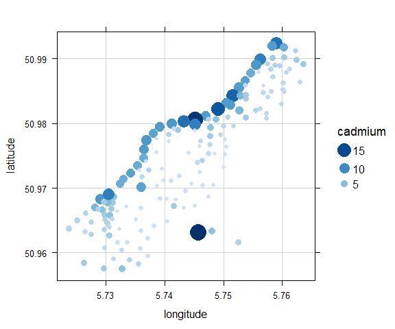

```r
loaPlot(cadmium~longitude*latitude, data=lat.lon.meuse)
```

Here, the **z** term, the cadmium data-series, is used to both color and size points plotted at **x** (**longitude**) and **y** (**latitude**) locations.

Additional arguments may be used to fine-tune the appearance of the plot, e.g. **groups** to group data within the plot:

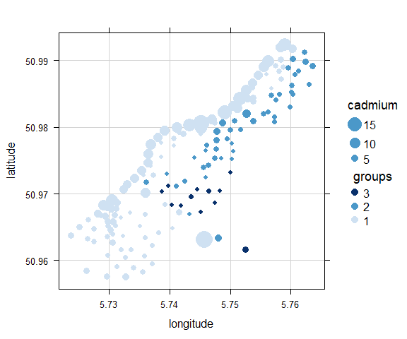

```r
loaPlot(cadmium~longitude*latitude, data=lat.lon.meuse,
        groups=lat.lon.meuse$soil)
```

Here, the plot color-codes the points according to **soil** (soil type 1-3), also in **lat.lon.meuse**.

> Note: By default, **groups** supersedes **z** as the coloring term when set but the points remain size scaled according to **z**.

By comparison, conditioning by **soil** type would produce:

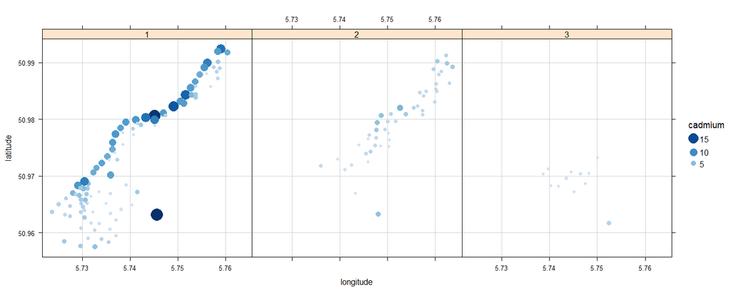

```r
loaPlot(cadmium~longitude*latitude|soil, data=lat.lon.meuse,
        layout=c(3,1))
```

This plots data of different **soil** types in discrete plot panels, each, by default, plotted using the same **x**, **y**, **z** and **groups** plot settings. The standard **lattice** argument **layout** is also used to plot the **lattice** sub-plots (or panels) in a row.

## loaPlot

Already introduced above, **loaPlot()** is a **z ~ x * y** bubble plot with default color (**col**) and size (**cex**) scaling linked to the **z** term unless **groups** are set, in which case **cex** is linked to **z** and **col** is linked to **groups**.

Many of the additional plot arguments are the same as in **lattice**, but some options have been enhanced or simplified, e.g.:

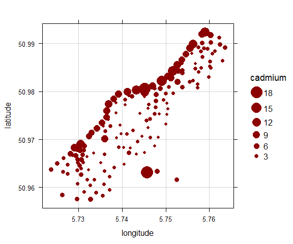

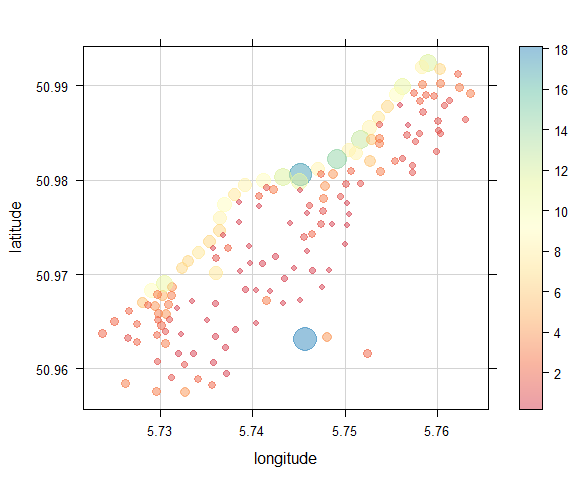

```r
#fixed col (but automatic z size scale)
#key scale manually extended
loaPlot(cadmium~longitude*latitude, data=lat.lon.meuse,
        col="darkred", key.z.at=c(3,6,9,12,15,18))
#replacing default blue scale with RColorBrewer palette
#adding transparency with alpha
#use color scale key like levelplot
loaPlot(cadmium~longitude*latitude, data=lat.lon.meuse,
        col.regions="Spectral", alpha=0.5,
        key.fun=draw.loaColorKey)
```

- As in **lattice**, **col** sets point color directly and **col.regions** sets the color palette colors are selected from. But **loa** also uses **RColorBrewer**[^6] to handle color ranges. So, the **loa** version of **col.regions** is a little more flexible than in **lattice**. For example, **loaPlot()** handles arguments like **col.regions = c(“green”, “red”)**.
- unlike **xyplot()** in **lattice**, **loaPlot()** automatically generates a plot key if it thinks you need one, but (like in **lattice**), **key** and **key…** arguments can be used to modify the key, e.g. **key = FALSE** to remove the key.
- I have tried to simplify some common arguments that use list structures in **lattice**. So, e.g. instead of using **key=list(z=list(at=c(…)))** you can use **key.z.at=c(…)** to manually set the points shown in the key. There are trade-offs in doing this, so it is currently only applied to selected cases in **loaPlot()**, but it does mean you can more easily change grid appearance with e.g. **grid.col=2** or **grid.lty=3**, etc.
- I also linked the **loaPlot()** argument **zlab** to **key.z.main** so you could rename the z key like you would the x and y axes.

> Note: The **loaPlot()** key can include **z** and **groups** elements. So, you need to specify which you want to change, hence **key.z.at=…** (not **key.at=…**).

Like **lattice** plots, **loaPlot()** also accepts other **panel** arguments to produce other plot types.

For example:

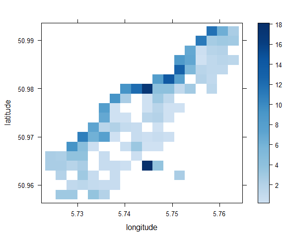

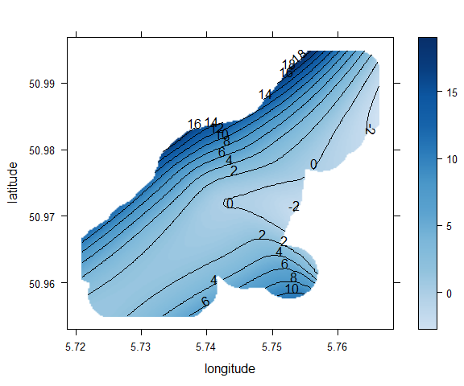

```r
#panel.binPlot
loaPlot(cadmium~longitude*latitude, data=lat.lon.meuse,
        panel=panel.binPlot, breaks=20, statistic=max)
#panel.surfaceSmooth
loaPlot(cadmium~longitude*latitude, data=lat.lon.meuse,
        panel=panel.surfaceSmooth, too.far=0.1)
```

- The **binPlot** panel expects **x**, **y** and **z** inputs and generates a heat map and color key similar to **levelplot()** but without the extra coding needed to get from **xyplot()** to **levelplot()** inputs. By default, it calculates means for each bin if **z** is supplied or generates a warning and counts bin sizes if not. You can also use arguments like **breaks** and **statistic** to change the number of bins and the way the binned data is handled.
- The **surfaceSmooth** panel also expects **x**, **y** and **z** and fits a color-surface to (**x**, **y**, **z**). By default, it extrapolates the surface to the **x** and **y** plot limits. However, the **too.far** argument (based on **too.far** in GAM visualizations in the **mgcv** package[^7]) can to used to limit the amount of extrapolation (0.1 = 10% of plot range from nearest point).

> Note: This option is not intended to be used with **loaPlot()** without additional option settings because it would just create over-plotting at each (**x**, **y**) point. However, it is useful when used with either **z** case panelling or specialist panels designed for use with mulitple **z** inputs, e.g.:

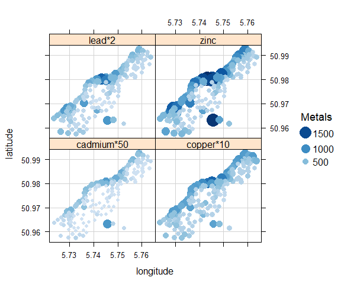

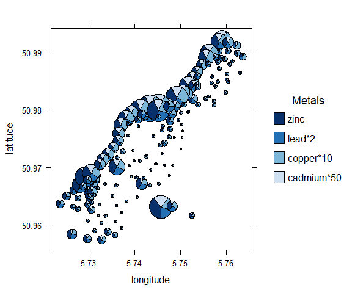

```r
#panel.zcases to condition by z1, z2, etc
loaPlot(cadmium*50+copper*10+lead*2+zinc~longitude*latitude,
          data=lat.lon.meuse, zlab="Metals",
          panel.zcases = TRUE)
#using the panel.zcasePiePlot and z1, z2, etc
loaPlot(cadmium*50+copper*10+lead*2+zinc~longitude*latitude,
          data=lat.lon.meuse, zcaselab="Metals",
          panel=panel.zcasePiePlot)
```

> For further information on **loaPlot()**, see in-package documentation **?loaPlot**.

## Other Plots

Other plots in **loa** include **RgoogleMapsPlot()**, **trianglePlot()**, **stackPlot()** and **loaBarPlot()**:

[figure not shown]

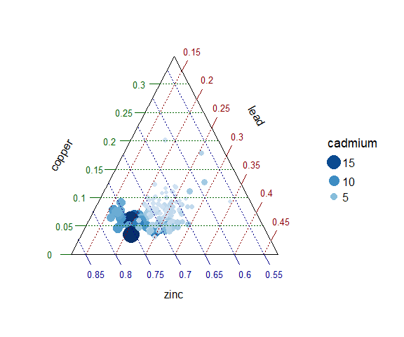

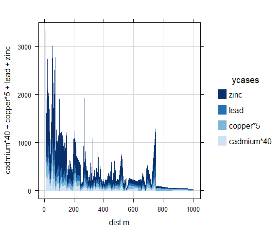

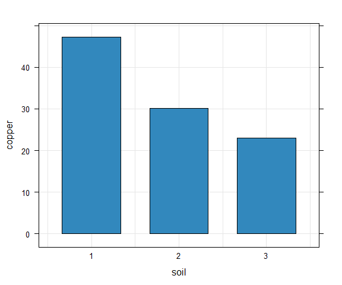

```r
#RgoogleMapsPlot
RgoogleMapsPlot(cadmium~latitude*longitude, data=lat.lon.meuse,
          map=roadmap.meuse)
#trianglePlot
trianglePlot(cadmium~copper+lead+zinc, data=lat.lon.meuse)
#stackPlot
stackPlot(cadmium*40+copper*5+lead+zinc~dist.m, data=lat.lon.meuse)
#loaBarPlot
loaBarPlot(copper~soil, data=lat.lon.meuse, stat=mean)
```

- **RgoogleMapsPlot()** is an extension of **loaPlot()** that adds a map layer to plots using the **RgoogleMaps** package[^8]. It uses a **z ~ latitude * longitude | cond** plot structure and accepts **loaPlot()** arguments to modify data layers as well as additional arguments to modify the map layer.
- **trianglePlot()** is a triangle (or ternary) plot that uses (a,b,c) axes and a **z ~ a + b + c | cond** plot structure.
- **stackPlot()** is a simple data-series stacking plot that uses a **y1 + y2 + … yn ~ x | cond** plot structure.
- **loaBarPlot()** is a simple bar plot that currently uses either a **y~x|cond** and **groups** plot structure or a more conventional **x, y, groups, cond** plot structure.

> For further information on these, see in-package documentation.

> Any thoughts, suggestions or problems, please let me know > Karl
[^1]: Sarkar D (2008). Lattice: Multivariate Data Visualization with R. Springer, New York. ISBN 978-0-387-75968-5, <URL: http://lmdvr.r-forge.r-project.org>.
[^2]: I presented earlier thoughts on this topic in e.g. Ropkins, K., Carslaw, D.C., Munir, S., Chen, H. R. (2012) lattice and RgoogleMaps: A practical framework for the development of new geovisualizations. ASA 2012 JSM. San Diego, US.
[^3]: Code handling and outputs may vary with package version.
[^4]: Pebesma EJ, Bivand RS (2005). “Classes and methods for spatial data in R.” R News, *5*(2), 9-13. <URL: https://CRAN.R-project.org/doc/Rnews/>., Bivand RS, Pebesma E, Gomez-Rubio V (2013). Applied spatial data analysis with R, Second edition. Springer, NY. <URL: https://asdar-book.org/>.
[^5]: This is described in early chapters of Sarkar D (2008). Lattice: Multivariate Data Visualization with R. Springer, New York. ISBN 978-0-387-75968-5, <URL: http://lmdvr.r-forge.r-project.org>.
[^6]: Neuwirth E (2014). RColorBrewer: ColorBrewer Palettes. R package version 1.1-2, <URL: https://CRAN.R-project.org/package=RColorBrewer>.
[^7]: Wood SN (2011). “Fast stable restricted maximum likelihood and marginal likelihood estimation of semiparametric generalized linear models.” Journal of the Royal Statistical Society (B), *73*(1), 3-36., Wood S, N., Pya, S“afken B (2016).”Smoothing parameter and model selection for general smooth models (with discussion)." Journal of the American Statistical Association, *111*, 1548-1575., Wood SN (2004). “Stable and efficient multiple smoothing parameter estimation for generalized additive models.” Journal of the American Statistical Association, *99*(467), 673-686., Wood S (2017). Generalized Additive Models: An Introduction with R, 2 edition. Chapman and Hall/CRC., Wood SN (2003). “Thin-plate regression splines.” Journal of the Royal Statistical Society (B), *65*(1), 95-114.
[^8]: Loecher M, Ropkins K (2015). “RgoogleMaps and loa: Unleashing R Graphics Power on Map Tiles.” Journal of Statistical Software, *63*(4), 1-18. <URL: http://www.jstatsoft.org/v63/i04/>.